# Selected Sections from Chapter 6: 6.1-6.3

[figure not shown]

© Scott Robison 2021 all rights reserved.

## Functions of Random Variables

> Please [read](https://github.com/chqngh-berkeley/personal/blob/master/Mathematical%20Statistics%20-%207th%20Edition%20-%20Wackerly.pdf) pages 296-298 from the text.

Pay particular attention to this section that tells you about when each method is particularly useful:

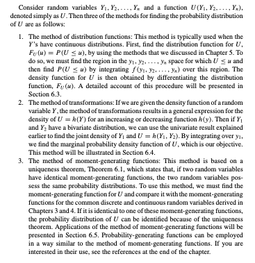

## 6.3 The Method of Distribution Functions

### Example 6.1

A process for refining sugar yields up to 1 ton of pure sugar per day, but the actual amount produced, $X$ , is a random variable because of machine breakdowns and other slowdowns. Suppose that $X$ has density function given by

$$\begin{align}f_X(x)=\begin{cases}
2x,& 0\le x\le 1\\
0,& \text{otherwise }\\
\end{cases}
\end{align}$$

The company is paid at the rate of $300 per ton for the refined sugar, but it also has a fixed overhead cost of $100 per day. Thus the daily profit, in hundreds of dollars, is $Y = 3X − 1$. Find the probability density function for $Y$.

### Solution

[video not shown]

[Example 6.1 hard copy solution](https://sarobiso.github.io/323course/text%20soltutions/323%206_1.pdf)

> Please continue [reading](https://github.com/chqngh-berkeley/personal/blob/master/Mathematical%20Statistics%20-%207th%20Edition%20-%20Wackerly.pdf) page 299 from the text.

### Example 6.2

In Example 5.4, we considered the random variables $X$ (the proportional amount of gasoline stocked at the beginning of a week) and $Y$ (the proportional amount of gasoline sold during the week). The joint density function of $X$ and $Y$ is given by

$$\begin{align}f_{XY}(x,y)=\begin{cases}
3x,& 0\le y\le x\le 1\\
0,& \text{otherwise }\\
\end{cases}
\end{align}$$

Find the probability density function for $Z=X-Y$, the proportional amount of gasoline remaining at the end of the week. Use the density function of $Z$ to find $E (Z )$.

### Solution

[video not shown]

[Example 6.2 hard copy solution](https://sarobiso.github.io/323course/text%20soltutions/323%206_2.pdf)

### Example 6.3

Let $(X , Y )$ denote a random sample of size $n = 2$ from the uniform distribution on the interval $(0, 1)$. Find the probability density function for $Z = X + Y$.

### Solution

[video not shown]

[Example 6.3 hard copy solution](https://sarobiso.github.io/323course/text%20soltutions/323%206_3.pdf)

> Please continue [reading](https://github.com/chqngh-berkeley/personal/blob/master/Mathematical%20Statistics%20-%207th%20Edition%20-%20Wackerly.pdf) pages 304-305 from the text.

A notable section:

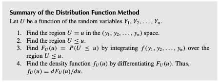

### Solution

[video not shown]

[Example 6.4 hard copy solution](https://sarobiso.github.io/323course/text%20soltutions/323%206_4.pdf)

> Please continue [reading](https://github.com/chqngh-berkeley/personal/blob/master/Mathematical%20Statistics%20-%207th%20Edition%20-%20Wackerly.pdf) Page 306.

### Additional Examples

Let $X$ be a continuous random variable with the following probability density function: $f(x)=3x^2$ for $0<x<1$. What is the probability density function of $Y=X^2$,$f(y)$?

[video not shown]

Let $X$ be a continuous random variable that follows an Exponential distribution, with mean $=\frac{1}{2}$. What is the probability density function of $Y=2X+1$,$f(y)$?

[video not shown]

Let $X_1$ and $X_2$ be two independent exponentially distributed random variables both with mean $\beta=1$. What is the probability density function of $Y=X_1+X_2$,$f(y)$?

[video not shown]

A holding tank has a capacity of 5000 litres is to be stocked at the beginning of the week. Because of various factors, when the tank is replenished it is not necessarily filled to capacity. As a result, the amount in this tank at the beginning of the week is a random variable $X$ that is measured in 1000s of litres.

The amount removed from the tank over the course of the week - the demand - fluctuates from week to week as well. Therefore, the amount removed in a week is a random variable $Y$.

The joint probability density function of $X$ and $Y$ is given by:

$$\begin{align}f_{X,Y}(x,y)=\begin{cases}
\frac{3x}{125},& 0\le y\le x \le 5\\
0,& \text{otherwise }\\
\end{cases}
\end{align}$$

Prior to the tank being refilled, a measurement is taken to record how much remains in the tank. The amount remaining is a random variable, expressed as a function of $X$ and >\(Y\).

Let Z represent the amount of gasoline remaining in the underground tank, or $Z = X- Y$. Find the probability density function of $Z$,$f_Z(z)$.

[video not shown]

> Please [**Practice**](https://github.com/chqngh-berkeley/personal/blob/master/Mathematical%20Statistics%20-%207th%20Edition%20-%20Wackerly.pdf) as many exercises from pages 307-310 as possible the odd questions have answers in the back of the text.

> This is where the real learning happens.